# HUGEN 2072 Project 7

# Instructions

Below is a guided tutorial to perform a genome-wide association study (GWAS) of height. Some code has been provided to you and some you will need to write yourself.

Project 7 has three components:

- **Scripting/coding**: read through this file and complete the pipeline by contributing your code *where indicated*.
- **Narrative**: knit the completed .Rmd to a code-integrated HTML report of your QC process and decisions.
  - Your report must answer all the questions and perform all the tasks indicated in the instructions/prompts given for each step.
  - You must submit a successfully-knitted HTML file and the `.Rmd` in order to earn a passing grade for this project.
  - Set up your report to flow like an actual document you might show your supervisor to summarize the QC project, emphasizing what was done at each step rather than the code used to do it (e.g., how many samples/SNPs were filtered out at a given step?)
  - **Submit your .Rmd and HTML to Canvas**
- **Presentation**: you will make a 10-min (maximum) recording of yourself with Panopto in which you summarize this GWAS. Instructions will given on Canvas.

In each part of this project you will implement one of the main steps of GWAS (some steps completed for you).

**Since the pipeline below is incomplete, some of the R code chunks are set to `eval=FALSE` so that knitting to HTML will succeed. You will need to change them to `eval=TRUE` as you progress so that your knitted document shows the results of running each chunk.**

**However, some chunks are very computationally intensive, produce a file that can be used without re-running the chunk. To make knitting to HTML faster, I have indicated which chunks you can set to `eval=FALSE` after you have produced the required files.**

**It is expected that you will copy this file somewhere to your directory on the CRC cluster so that you can use the RStudio Server, where all the packages you need have been installed already.**

## Part 0 - Setup Workspace and Load Sample Data

First, load the packages we’ll be using.

```r
# Load the required packages for the project (Install them if necessary)

library("tidyverse", quietly = TRUE)
library("SeqArray", quietly = TRUE)
library("SeqVarTools", quietly = TRUE)
library("Biobase", quietly = TRUE)
library("GENESIS", quietly = TRUE)
library("GGally", quietly = TRUE)
library("qqman", quietly = TRUE)

# Close any open GDS files before proceeding (think of this as starting off with a 'blank slate')

showfile.gds(closeall = T, verbose = T)
```

```
p7_sample_info.RData
p7_variant_info.RData
p7_pca.RData
p7_grm.RData
p7_imputed_data.gds
```

To start, load in the sample information file and examine it.

```r
# path to folder for project
my_folder <- "/ix1/hugen2072-2026s/p7/"


# load the sample info file
load(paste0(my_folder, "p7_sample_info.RData"), verbose = TRUE)
```

```
## Loading objects:
##   sample.info
```

## Part 0 - Report

Describe the sample to use in this study. How many individuals are there? What measurements (variables) are there?

Describe the distribution of the phenotype height. Does it vary by sex or population (pop)?

Based on your findings, do you think you should include sex or pop as covariates in a GWAS for height?

```r
# Your code goes here
sample.data = sample.info %>%
  pData()

# number of samples
nrow(sample.data %>% distinct(sample.id))
```

```
## [1] 2548
```

```r
glimpse(sample.data)
```

```
## Rows: 2,548
## Columns: 4
## $ sample.id <chr> "HG00096", "HG00097", "HG00099", "HG00100", "HG00101", "HG00…
## $ sex       <chr> "male", "female", "female", "female", "male", "female", "mal…
## $ pop       <chr> "EUR", "EUR", "EUR", "EUR", "EUR", "EUR", "EUR", "EUR", "EUR…
## $ height    <dbl> 170.5518, 155.1560, 157.5750, 151.2360, 161.9721, 148.3681, …
```

```
## # A tibble: 2 × 9
##   sex    count median    sd   q25  mean   q75   min   max
##   <chr>  <int>  <dbl> <dbl> <dbl> <dbl> <dbl> <dbl> <dbl>
## 1 female  1296   162.  6.45  158.  162.  167.  142.  182.
## 2 male    1252   174.  6.61  170.  174.  179.  155.  194.
```

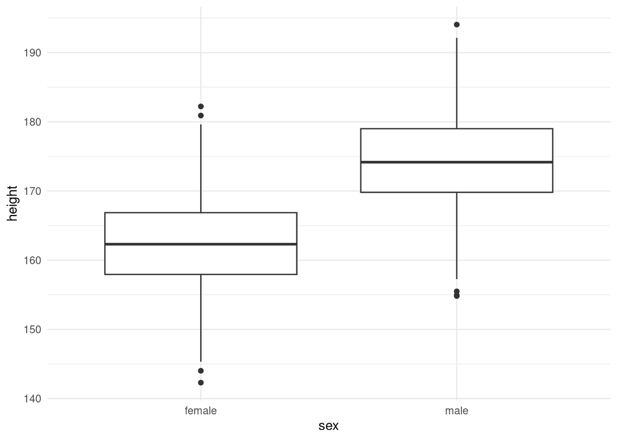

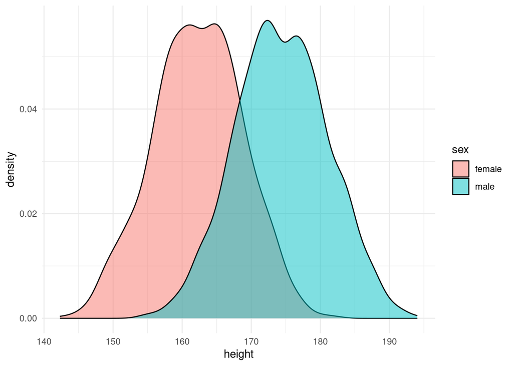

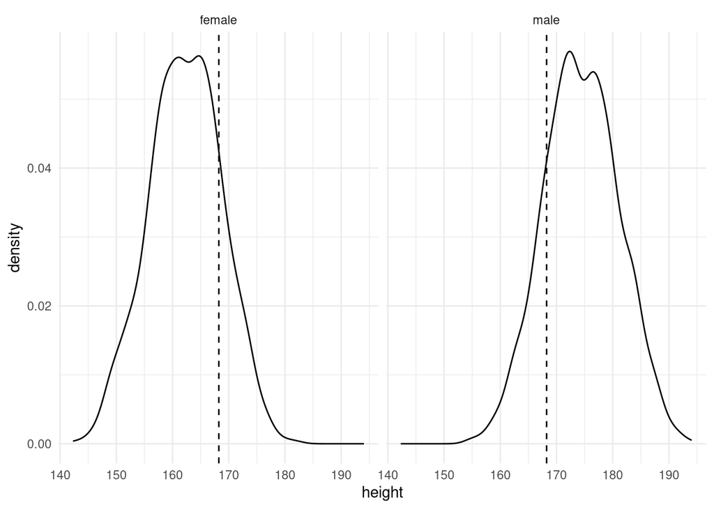

```r
# get some preliminary summary statistics across our two grouped fields
get_height_summary_by_group <- function(data, group) {
  # summary stats
  summ = data %>%
  group_by(
    !!sym(group)
  ) %>%
  summarise(
    count = n(),
    median = median(height),
    sd = sd(height),
    q25 = quantile(height, 0.25),
    mean = mean(height),
    q75 = quantile(height, 0.75),
    min = min(height),
    max = max(height)
  )
  print(summ)
  # graphing setup
  base_plot = data %>%
    ggplot() +
    aes(
      x = !!sym(group),
      y = height
    )
  # boxplots
  bp = data %>%
    ggplot() +
    aes(
      x = !!sym(group),
      y = height
    ) +
    geom_boxplot() +
    theme_minimal()
  print(bp)
  # density plots across groups
  # one plotted overtop
  dens_layers = data %>%
    ggplot() +
    aes(
      x = height,
      fill = !!sym(group)
    ) +
    geom_density(alpha = 0.5) +
    theme_minimal()
  print(dens_layers)
  # one faceted
  dens_facet = data %>%
    ggplot() +
    aes(
      x = height,
    ) +
    geom_vline(
      aes(
        xintercept = mean(height)),
        linetype = "dashed"
    ) +
    facet_wrap(group) +
    geom_density(alpha = 0.5) +
    theme_minimal()
  print(dens_facet)
}

# summary stats by sex
get_height_summary_by_group(sample.data, "sex")
```

```r
# summary stats by pop
get_height_summary_by_group(sample.data, "pop")
```

```
## # A tibble: 6 × 9
##   pop     count median    sd   q25  mean   q75   min   max
##   <chr>   <int>  <dbl> <dbl> <dbl> <dbl> <dbl> <dbl> <dbl>
## 1 AFR       671   174.  7.88  168.  174.  181.  158.  194.
## 2 AMR       348   165.  7.22  159.  165.  171.  149.  182.
## 3 EAS       515   169.  7.71  163.  169.  176.  148.  187.
## 4 EUR       521   161.  7.73  155.  161.  167.  142.  180.
## 5 EUR,AFR     1   175. NA     175.  175.  175.  175.  175.
## 6 SAS       492   169.  7.32  162.  168.  174.  151.  185.
```

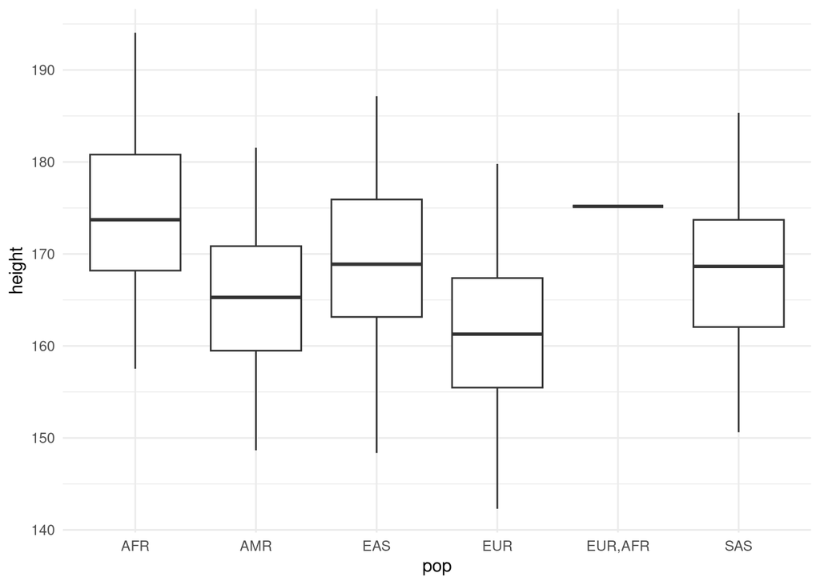

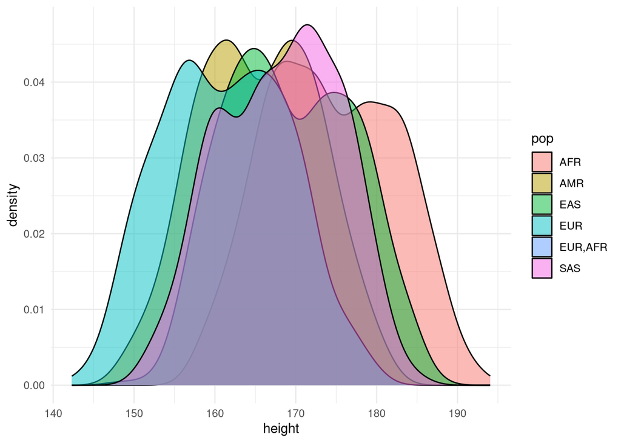

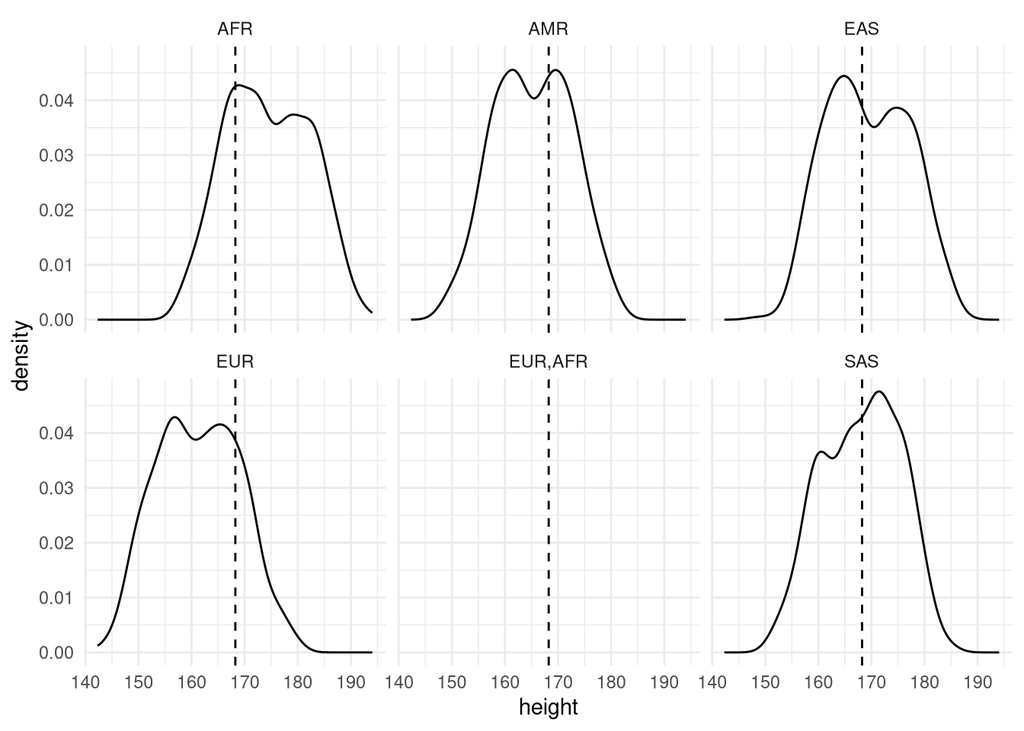

```r
# distribution for the height variable across all participants
# overall summary
sample.data %>%
  summarise(
    count = n(),
    median = median(height),
    sd = sd(height),
    q25 = quantile(height, 0.25),
    mean = mean(height),
    q75 = quantile(height, 0.75),
    min = min(height),
    max = max(height)
  )
```

```
##   count   median       sd      q25     mean     q75      min      max
## 1  2548 168.1576 8.912979 161.7598 168.2403 174.494 142.2978 194.0495
```

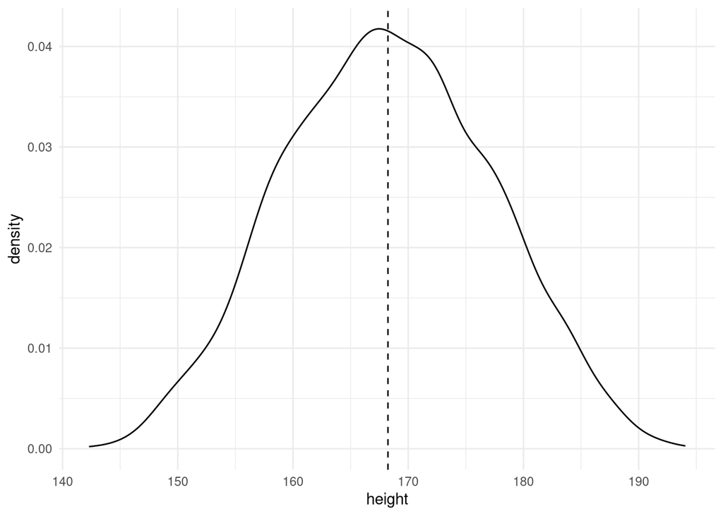

```r
# overall distribution
sample.data %>%
  ggplot() +
  aes(
    x = height,
  ) +
  geom_vline(
    aes(
      xintercept = mean(height)),
      linetype = "dashed"
  ) +
  geom_density(alpha = 0.5) +
  theme_minimal()
```

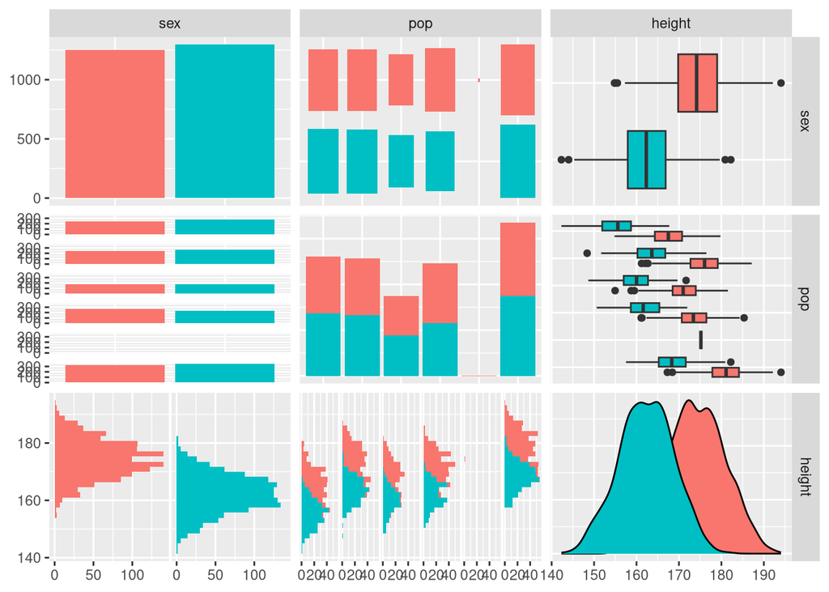

```r
# quick overview using the GGally package that we learned in 2073
# https://ggobi.github.io/ggally/articles/ggpairs.html
library(GGally)
data.factored = sample.data %>%
    select(-sample.id) %>%
    mutate(
      sex = as_factor(sex),
      pop = as_factor(pop)
    )
ggpairs(
  data.factored,
  mapping = aes(color = sex)
)
```

The sample from this study includes the height, sex, and population/heritage of 2,548 participants. Sex is a binary “male”/“female” coding and population is across 6 options with an inclusion of a single participant that is of both European and African descent. The height outcome does appear to be normally distributed, but does appear to vary with both sex and population. Male participants appear to be taller (174) compared to female participants (162). Height also appears to differ across heritage. I would use both sex and pop as covariates on our height GWAS.

## Part 1 - Imputed genotypes

Imputed genotypes were obtained using the TOPMed Imputation Server (and then downsampled for computational ease). Information about the resulting variants is in `p7_variant_info.RData`. The imputed genotypes themselves have been converted to a Seq GDS file, `p7_imputed_data.gds`.

Load in the SNP information file and explore it. The columns are:

- snp.id: the variant id used in the GDS
- chr: chromosome
- pos: position
- alleles: allele codes (ref, alt)
- af: alt allele frequency
- r2: imputation r-squared
- genotyped: TRUE if genotyped, FALSE if imputed

```r
# load in SNP information file
load(paste0(my_folder, "p7_variant_info.RData"), verbose = TRUE)
```

```
## Loading objects:
##   snp.info
```

```r
# Your code goes here
glimpse(snp.info)
```

```
## Rows: 647,629
## Columns: 7
## $ snp.id    <int> 1, 2, 3, 4, 5, 6, 7, 8, 9, 10, 11, 12, 13, 14, 15, 16, 17, 1…
## $ chr       <chr> "1", "1", "1", "1", "1", "1", "1", "1", "1", "1", "1", "1", …
## $ pos       <int> 770092, 777533, 810516, 813432, 816570, 824318, 827665, 8276…
## $ alleles   <chr> "G,A", "G,T", "A,G", "G,C", "C,T", "CAT,C", "C,G", "C,T", "C…
## $ af        <dbl> 2.74725e-05, 5.88697e-07, 1.96232e-07, 1.96232e-06, 4.90581e…
## $ r2        <dbl> 0.018587301, 0.000999412, 0.000999804, 0.000998040, 0.021235…
## $ genotyped <lgl> FALSE, FALSE, FALSE, FALSE, FALSE, FALSE, FALSE, FALSE, FALS…
```

```r
snp_by_chr = snp.info %>%
  select(
    chr
  ) %>%
  mutate(
    chr = as.integer(chr)
  ) %>%
  group_by(
    chr
  ) %>%
  summarise(
    count = n()
  )

snp_by_chr
```

```
## # A tibble: 22 × 2
##      chr count
##    <int> <int>
##  1     1 29359
##  2     2 29087
##  3     3 29106
##  4     4 29064
##  5     5 29100
##  6     6 29005
##  7     7 29311
##  8     8 29420
##  9     9 29679
## 10    10 29306
## # ℹ 12 more rows
```

```r
mean_chr_count = mean(snp_by_chr$count)
mean_chr_count
```

```
## [1] 29437.68
```

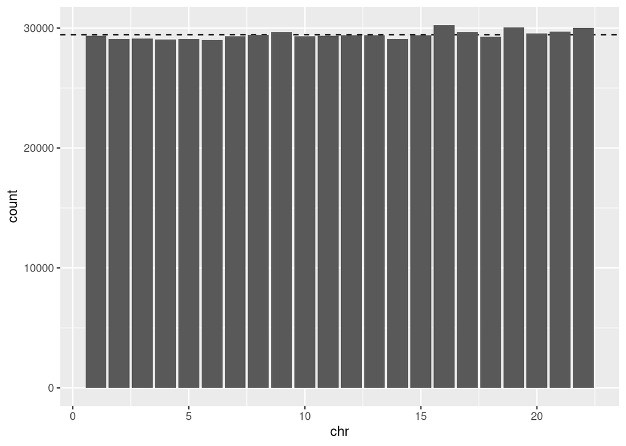

```r
snp_by_chr %>%
    ggplot() +
    aes(
      x = chr,
      y = count
    ) +
    geom_hline(
      aes(
        yintercept = mean_chr_count
      ),
      linetype = "dashed"
    ) +
    geom_col()
```

```r
    theme_minimal()
```

[output not shown]

[output cut: 313 more lines]

[output not shown]

Decide on reasonable filters for these SNPs to be included in a GWAS for this sample. Base this decision on your exploration of the `snp.info` and content from class. You will be guided to think about specific aspects for these filters in the reporting section below.

Create a list of SNPs to use for downstream analyses, implementing your chosen filters. **You will need to put your criteria for SNPs to include inside the `filter` function.** Running the template code as is will not perform any filtering.

```r
# make list of snp.ids for SNPs passing filters using snp.info
snps.keep <- snp.info %>%
  filter(
    af > 0.01,
    r2 > 0.8
  ) %>%
  pull(snp.id)
```

## Part 1 - Report

How many variants are present in the imputed genotypes GDS file?

How many variants are imputed and how many are genotyped?

Make a plot showing the distribution of imputation quality (r2). What do you think is a reasonable threshold to set for keeping SNPs based on this?

Make a plot showing the distribution of allele frequencies. What do you think is a reasonable threshold to set for keeping SNPs based on this?

How many variants are you going to include in your analyses (those that have high imputation quality and are common enough to include in a GWAS)?

```r
# Your code goes here

# check if there is any missingness
anyNA(snp.info)
```

```
## [1] FALSE
```

```r
# number of variants
nrow(snp.info)
```

```
## [1] 647629
```

```r
# number of imputed and genotyped variants
snp.info %>%
  group_by(
    genotyped
  ) %>%
  summarize(
    count = n()
  )
```

```
## # A tibble: 1 × 2
##   genotyped  count
##   <lgl>      <int>
## 1 FALSE     647629
```

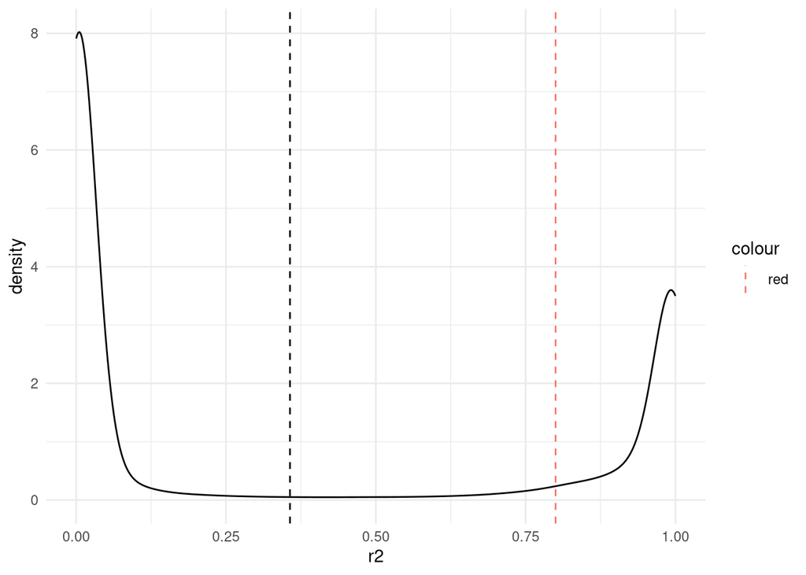

```r
show_dist <- function(data, var, estimate_line) {
  data %>%
    ggplot() +
    aes(
      x = !!sym(var),
    ) +
    geom_vline(
      aes(
        xintercept = mean(!!sym(var))
      ),
      linetype = "dashed"
    ) +
    geom_vline(
      aes(
        xintercept = estimate_line,
        color = "red"
      ),
      linetype = "dashed"
    ) +
    geom_density(alpha = 0.5) +
    theme_minimal()
}

# distribution of R2
snp.info %>%
  show_dist("r2", 0.8)
```

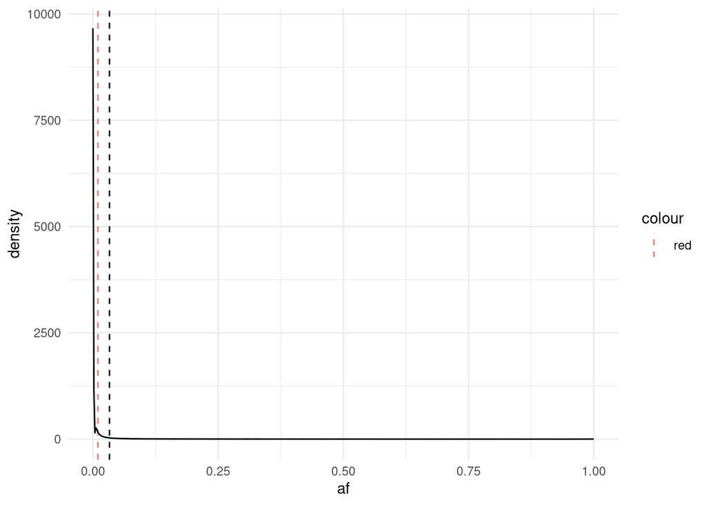

```r
# distribution of allele frequencies
snp.info %>%
  show_dist("af", 0.01)
```

```r
# number of variants after filtering
length(snps.keep)
```

```
## [1] 103740
```

## Part 2 - Principle Components of Ancestry

You have been provided with pre-calculated principal components of ancestry in `p7_pca.RData`. This file contains two data objects: `mypcair` the output from pcair and `pca` a data frame with 32 PCAs and sample.id.

Merge this with the sample.info information and create plots of the PCAs (scree plot, parallel coordinates plot, and pairwise scatterplots). **You will need to decide how many PCAs to retain for analysis.**

```r
# load PCA object
load(paste0(my_folder, "p7_pca.RData"), verbose = TRUE)
```

```
## Loading objects:
##   pca
##   mypcair
```

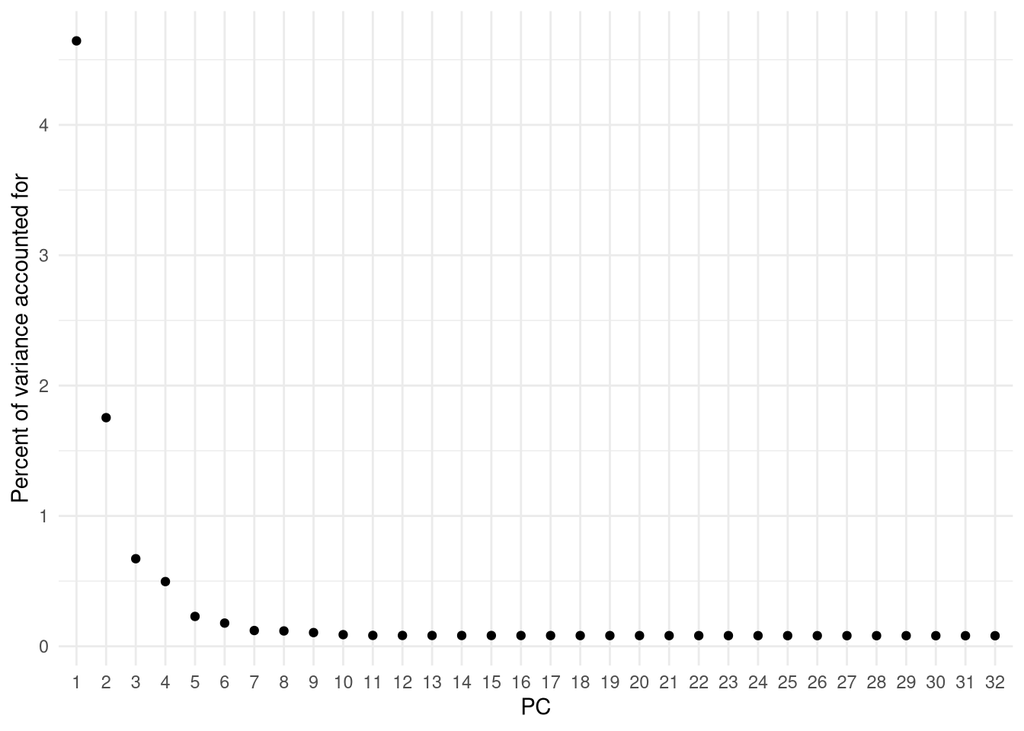

```r
# Your code goes here

# merge the data
merged_sample_pca = sample.data %>%
  left_join(
    pca,
    by = "sample.id"
  )

# data for the scree plot
n_pca = (ncol(pca) - 1)
scree_data = data.frame(
  pc = 1:n_pca,
  varprop = mypcair$varprop[1:n_pca]
)

# scree plot
scree_data %>%
  ggplot() +
  aes(
    x = factor(pc),
    y = 100 * varprop
  ) +
  geom_point() +
  theme_bw() +
  xlab("PC") +
  ylab("Percent of variance accounted for") +
  theme_minimal()
```

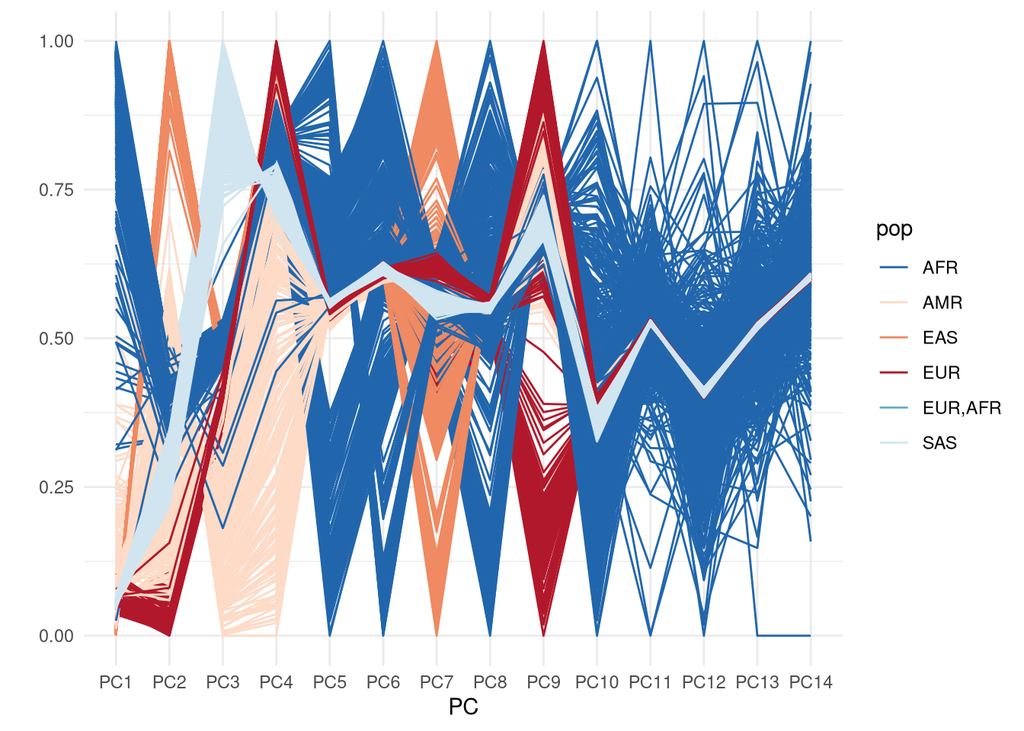

```r
# parallel coordinated plot (note, loaded GGally above)
library(RColorBrewer)

pop_names = merged_sample_pca$pop %>% unique()
n_pops = length(pop_names)

pop.cols = setNames(
  brewer.pal(
    n = n_pops,
    "RdBu"
  ),
  pop_names
)

merged_sample_pca %>%
  ggparcoord(
    columns = 5:18,
    groupColumn = "pop",
    scale = "uniminmax"
  ) +
  scale_color_manual(
    values = pop.cols
  ) +
  xlab("PC") + ylab("") +
  theme_minimal()
```

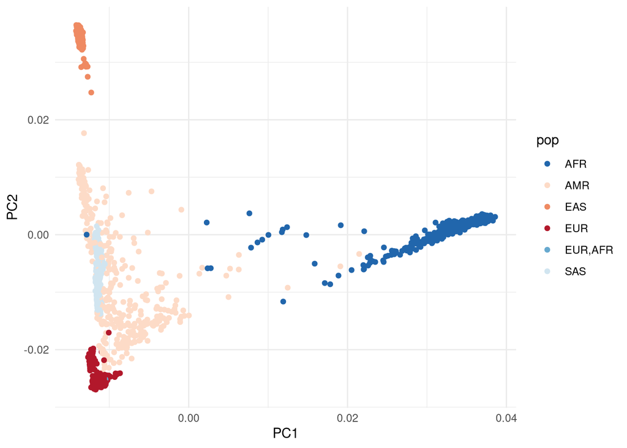

```r
# pairwise scatterplot (first two components)
merged_sample_pca %>%
  ggplot() +
  aes(
    PC1,
    PC2,
    color = pop
  ) +
  geom_point(
  ) +
  scale_color_manual(
    values = pop.cols
  ) +
  scale_shape_binned() +
  theme_minimal()
```

## Part 2 - Report

How many principal components of ancestry will you include as covariates in the GWAS? Why did you choose this number?

```r
# Your code goes here

# NOTE: the "EUR,AFR" ancestry participant landed directly within the EUR population in PCA...
# Would probably just recode them to EUR with the following...

corrected_ancestry = merged_sample_pca %>%
  mutate(
    pop = if_else(
      pop == "EUR,AFR",
      "EUR",
      pop
    )
  )

get_height_summary_by_group(corrected_ancestry, "pop")
```

```
## # A tibble: 5 × 9
##   pop   count median    sd   q25  mean   q75   min   max
##   <chr> <int>  <dbl> <dbl> <dbl> <dbl> <dbl> <dbl> <dbl>
## 1 AFR     671   174.  7.88  168.  174.  181.  158.  194.
## 2 AMR     348   165.  7.22  159.  165.  171.  149.  182.
## 3 EAS     515   169.  7.71  163.  169.  176.  148.  187.
## 4 EUR     522   161.  7.75  155.  161.  167.  142.  180.
## 5 SAS     492   169.  7.32  162.  168.  174.  151.  185.
```

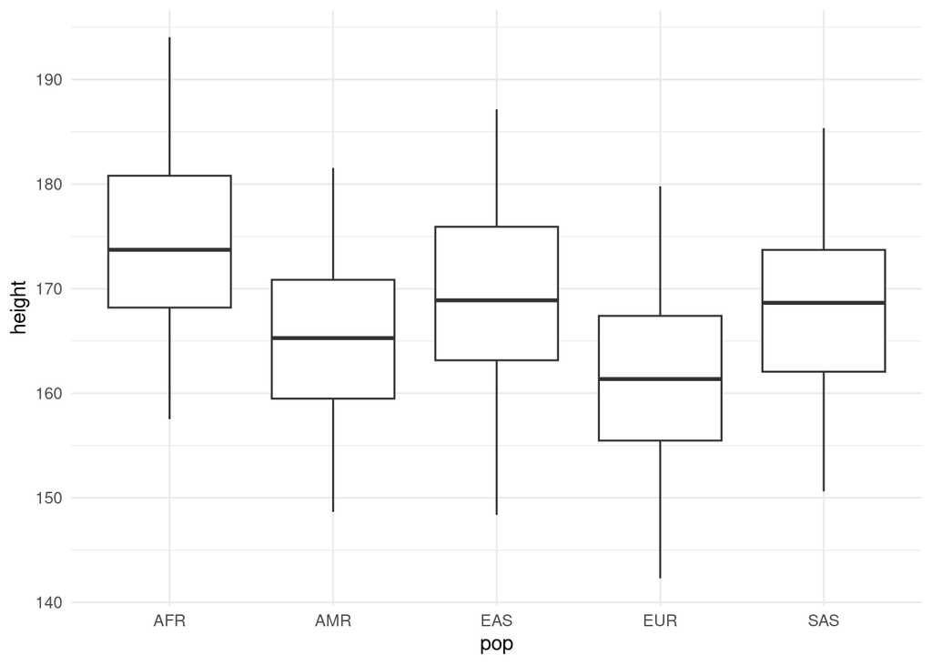

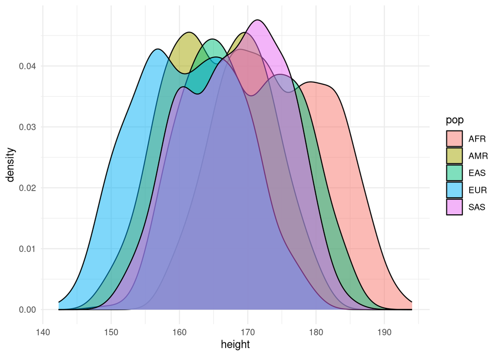

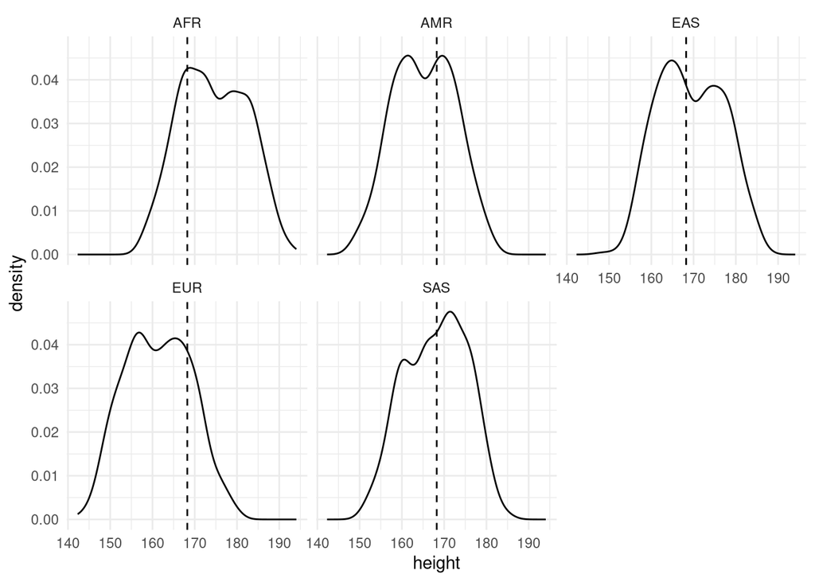

## Part 3 - Null Model

PC-Relate was already run and the results are stored in `p7_grm.RData`. This file contains a genetic relatedness matrix (called `GRM`) and the results from pc-relate `mypcrelate`.

Create a kinship plot to examine relatedness among the sample.

```r
# Load in pc-relate results
load(paste0(my_folder, "p7_grm.RData"), verbose = TRUE)
```

```
## Loading objects:
##   mypcrelate
##   GRM
```

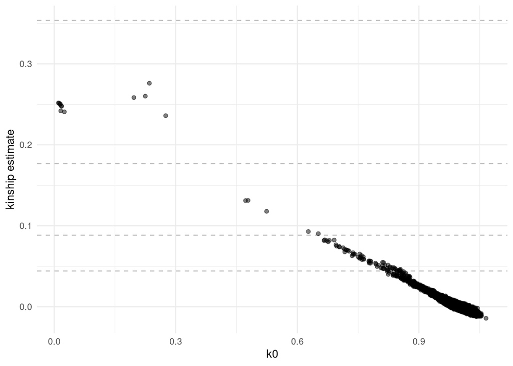

```r
# Your code goes here
kinship <- mypcrelate$kinBtwn

kinship %>%
  ggplot() +
  aes(
    x = k0,
    y = kin
  ) +
  geom_hline(
    yintercept = 2^(-seq(3,9,2)/2),
    linetype="dashed",
    color="grey"
  ) +
  geom_point(alpha = 0.5) +
  ylab("kinship estimate") +
  theme_minimal()
```

Decide on a null model to use for a GWAS of height for this sample. You will be guided to think about specific aspects for these filters in the reporting section below.

Run the null model in the chunk below. You will need to supply the code for running the null model.

```r
# Your code goes here

# set up the annotated data frame
metadata = data.frame(
  labelDescription = c(
    varMetadata(sample.info)$labelDescription,
    paste0(
      "PC",
      1:n_pca
    )
  )
)

annot = AnnotatedDataFrame(
  merged_sample_pca,
  metadata
)

# generate the nul model
nullmod_linear <- fitNullModel(
  annot,
  outcome = "height",
  covars = c(
    "sex",
    "pop",
    paste0(
      "PC",
      1:11
    )
  ),
  cov.mat = GRM,
  family = "gaussian",
  sample.id = NULL,
  two.stage = TRUE)
```

```
## Computing Variance Component Estimates...
```

```
## Sigma^2_A     log-lik     RSS
```

```
## [1]    39.7205964    39.7205964 -7415.7791518     0.2568455
## [1]    13.1589921    37.4986143 -7415.4708770     0.4024771
## [1]     3.9902946    27.8563966 -7415.4129813     0.6400737
## [1]     0.6356117    13.3019512 -7415.4182832     1.4624651
## [1]     1.269002    17.076059 -7415.413516     1.111110
## [1]     1.816331    18.363428 -7415.411561     1.010103
## [1]     1.989746    18.391952 -7415.411368     1.000100
## [1]     2.016141    18.367620 -7415.411363     1.000000
```

```
## Computing Variance Component Estimates...
## Sigma^2_A     log-lik     RSS
```

```
## [1]     2.0161411    18.3676203 -7415.2618598     0.9998818
## [1]     1.627314    18.753712 -7415.260699     1.000002
## [1]     1.571441    18.809581 -7415.260675     1.000000
## [1]     1.563325    18.817692 -7415.260674     1.000000
```

## Part 3 - Report

Do you think you should account for relatedness with a genetic relatedness matrix?

What type of model should be used for a GWAS of height (linear or logistic)?

Does the height phenotype appear to follow a normal distribution closely enough, or do you think we should use an inverse normal transformed phenotype here? Explain.

What covariates are included in the null model? (Hint: think back to your findings in part 0 and part 2.)

```r
# Your code goes here
```

## Part 4 - Association Test

Now, you will finally run the genotype association tests for the GWAS. The imputed genotypes are available as a Seq GDS file, `p7_imputed_data.gds`. First, create a SeqVarData object by merging the gds file with the annotated data frame that includes the PCAs from Part 2. Then, use `seqSetFilter()` to keep only the good SNPs you created in Part 1 (`snps.keep`). Using this and the null model you created in Part 3, run the single variant association tests genome-wide using an additive genetic model using the imputed dosages.

```r
# read in GDS file
gdsfile <- paste0(my_folder, "p7_imputed_data.gds")
gds <- seqOpen(gdsfile)
gds
```

```
## Object of class "SeqVarGDSClass"
## File: /ix1/hugen2072-2026s/p7/p7_imputed_data.gds (481.4M)
## +    [  ] *
## |--+ description   [  ] *
## |--+ sample.id   { Str8 2548 LZMA_ra(7.84%), 1.6K } *
## |--+ variant.id   { Int32 647629 LZMA_ra(6.24%), 157.9K } *
## |--+ position   { Int32 647629 LZMA_ra(48.6%), 1.2M } *
## |--+ chromosome   { Str8 647629 LZMA_ra(0.03%), 489B } *
## |--+ allele   { Str8 647629 LZMA_ra(18.1%), 526.3K } *
## |--+ genotype   [  ] *
## |  |--+ data   { Bit2 2x2548x647629 LZMA_ra(4.04%), 31.8M } *
## |  |--+ extra.index   { Int32 3x0 LZMA_ra, 18B } *
## |  \--+ extra   { Int16 0 LZMA_ra, 18B }
## |--+ phase   [  ]
## |  |--+ data   { Bit1 2548x647629 LZMA_ra(0.01%), 29.5K } *
## |  |--+ extra.index   { Int32 3x0 LZMA_ra, 18B } *
## |  \--+ extra   { Bit1 0 LZMA_ra, 18B }
## |--+ annotation   [  ]
## |  |--+ id   { Str8 647629 LZMA_ra(36.2%), 2.3M } *
## |  |--+ qual   { Float32 647629 LZMA_ra(0.02%), 533B } *
## |  |--+ filter   { Int32,factor 647629 LZMA_ra(0.02%), 533B } *
## |  |--+ info   [  ]
## |  |  |--+ AF   { Float32 647629 LZMA_ra(46.2%), 1.1M } *
## |  |  |--+ MAF   { Float32 647629 LZMA_ra(46.0%), 1.1M } *
## |  |  |--+ AVG_CS   { Float32 647629 LZMA_ra(22.8%), 577.6K } *
## |  |  |--+ R2   { Float32 647629 LZMA_ra(53.8%), 1.3M } *
## |  |  |--+ ER2   { Float32 647629 LZMA_ra(15.1%), 380.9K } *
## |  |  |--+ IMPUTED   { Bit1 647629 LZMA_ra(13.6%), 10.8K } *
## |  |  \--+ TYPED   { Bit1 647629 LZMA_ra(68.1%), 53.9K } *
## |  \--+ format   [  ]
## |     |--+ DS   [  ] *
## |     |  \--+ data   { Float32 2548x647629 LZMA_ra(1.42%), 89.2M } *
## |     |--+ GP   [  ] *
## |     |  \--+ data   { Float32 2548x1942887 LZMA_ra(1.23%), 232.3M } *
## |     \--+ HDS   [  ] *
## |        \--+ data   { Float32 2548x1295258 LZMA_ra(0.95%), 119.2M } *
## \--+ sample.annotation   [  ]
```

```r
# Your code goes here

seqData <- SeqVarData(
  gds,
  sampleData = annot
)

seqSetFilter(
  seqData,
  variant.id = snps.keep
)
```

```
## # of selected variants: 103,740
```

```r
seqIterator <- SeqVarBlockIterator(
  seqData,
  variantBlock = 5000,
  verbose = TRUE
)
```

```
## # of selected variants: 5,000
```

```r
assoc_linear <- assocTestSingle(
  seqIterator,
  null.model = nullmod_linear,
  geno.coding = "additive",
  male.diploid = TRUE,
  imputed = TRUE
)
```

```
## # of selected samples: 2,548
```

```
## Using 22 CPU cores
```

```r
seqClose(gds)
```

## Part 4 - Report

Make Q-Q plot for these GWAS results (not the phenotype) and calculate the genomic inflation factor, $\lambda_GC$. Does there appear to be any inflation in these results?

Make a Manhattan plot for these results. How many genome-wide significant regions (p < 5e-8) do you observe?

Which variant is the most significantly associated with height? What is the effect size estimate from the model for this variant?

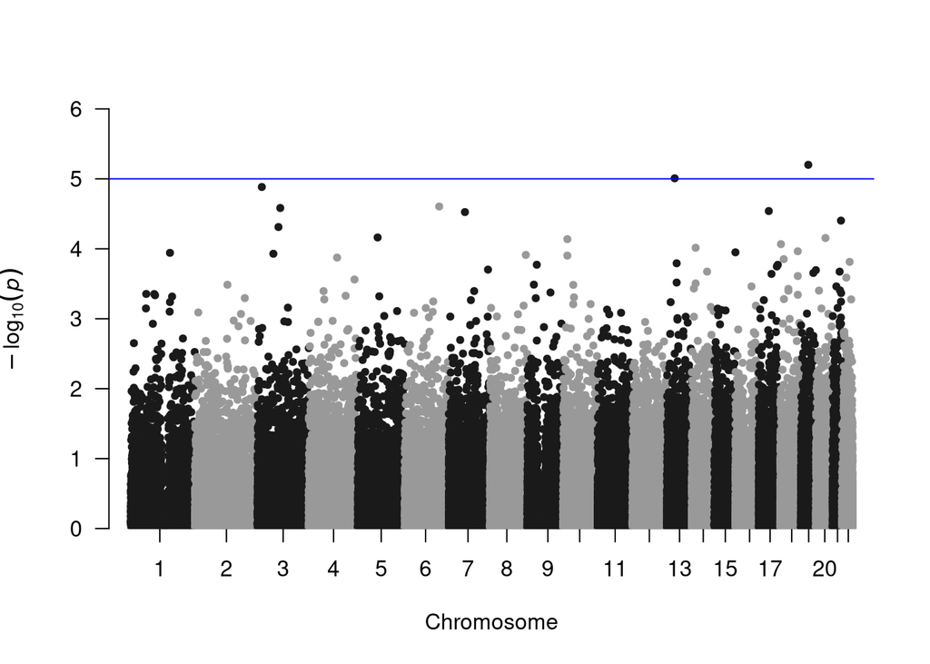

```r
# Your code goes here

library(qqman)

assoc_linear <- assoc_linear %>%
  mutate(
    chr = as.numeric(chr),
    snp = paste(
      chr, pos, sep=":"
    )
  )

assoc_pruned = assoc_linear %>%
  filter(
    -log10(Score.pval) > 2
  )

# manhattan plot
qqman::manhattan(
  # assoc_pruned,
  assoc_linear,
  chr = "chr",
  bp = "pos",
  snp = "snp",
  p = "Score.pval"
)
```

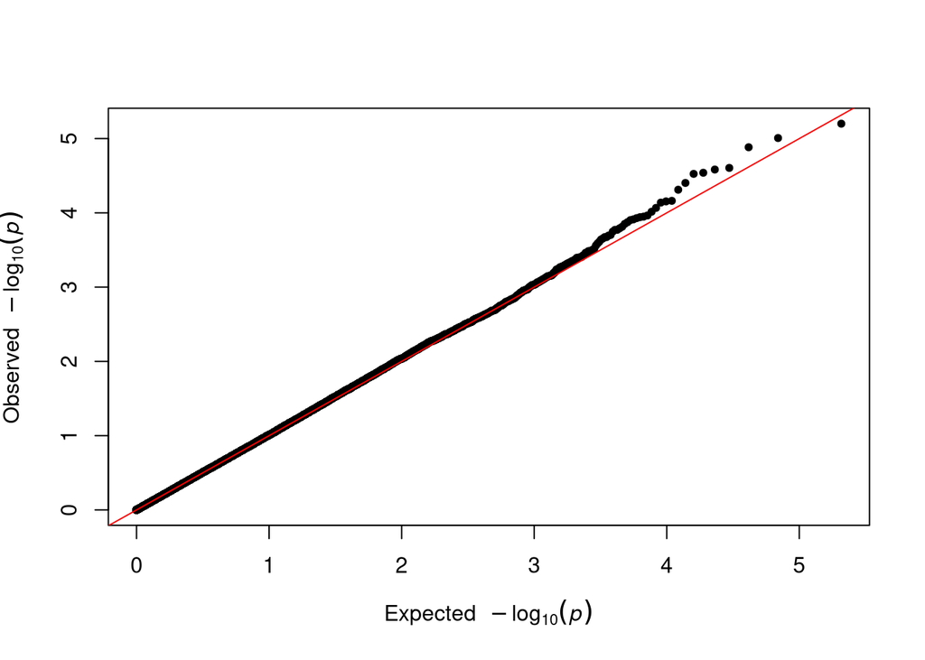

```r
# qqplot
qq(assoc_linear$Score.pval)
```

```r
# calculate lambda
lambda <- unname(
  quantile(
    assoc_linear$Score.Stat^2, probs = 0.5, na.rm=TRUE
  ) /
  qchisq(0.5, df = 1)
)
lambda
```

```
## [1] 1.013981
```

```r
# create a table of the top variant
top = assoc_linear %>%
  arrange(Score.pval)
top = top[1:10,]

# data dictionary of the output
# https://www.bioconductor.org/packages//release/bioc/vignettes/GENESIS/inst/doc/assoc_test.html

# use topr to annotate our top 10 SNPs to closest gene
# install.packages("topr")
library(topr)
genes = annotate_with_nearest_gene(
  top %>%
    mutate(
      CHROM = chr,
      POS = pos
    ) %>%
    select(CHROM, POS)
) %>%
  mutate(
    snp = paste(
      CHROM, POS, sep=":"
    )
  ) %>%
  select(
    snp, Gene_Symbol
  )

top %>%
  mutate(
    Beta = Est,
    PVal = Score.pval,
    Freq = freq,
  ) %>%
  select(
    snp, PVal, Beta, Freq, variant.id
  ) %>%
  left_join(
    snp.info %>%
      mutate(
        variant.id = snp.id
      ) %>%
      separate(
        alleles,
        into = c(
          "REF", "ALT"
        ),
        sep = ","
      ) %>%
      select(
        REF, ALT, variant.id
      ),
    by = "variant.id"
  ) %>%
  left_join(
    genes,
    by = "snp"
  ) %>%
  mutate(
    SNP = snp,
    Gene = Gene_Symbol,
    NegLogPVal = -log10(PVal)
  ) %>%
  select(
    SNP, REF, ALT, PVal, NegLogPVal, Beta, Freq, Gene
  )
```

```
##            SNP REF ALT         PVal NegLogPVal       Beta       Freq      Gene
## 1  19:28492903   C   T 6.303618e-06   5.200410  0.8675459 0.12582241  MAN1A2P1
## 2  13:47712209   A   T 9.832869e-06   5.007320 -0.6443187 0.57272076    SUCLA2
## 3   3:16609598   A   G 1.308649e-05   4.883177 -0.6617960 0.30671115      DAZL
## 4  6:133354937   A   G 2.483920e-05   4.604862  1.1563925 0.06384105      EYA4
## 5   3:87943138   G   T 2.612338e-05   4.582971  0.7075006 0.18262520     HTR1F
## 6  17:38917279   G   A 2.886476e-05   4.539632  0.7661011 0.14292327     LASP1
## 7   7:62389656   T   C 2.988019e-05   4.524617 -2.6109034 0.01059655 RNU6-417P
## 8  21:42200563   G   A 3.957186e-05   4.402614  2.4802444 0.01216797     ABCG1
## 9   3:80956591   G   C 4.885781e-05   4.311066  2.2391697 0.01236656 LINC02027
## 10  5:76521950  TA   T 6.891524e-05   4.161685  0.7293189 0.19147998    IQGAP2
```